# Econometria III Aula 4

Mestrado Profissional em Administração

Prof. Dr. Washington Santos da Silva

09/11/2026

## Programação da aula

### Aula anterior

- Inferência em modelos para dados em painel

### Hoje

- Dinâmica e Endogeneidade em Modelos para Dados em Painel
- Visão Geral do Método dos Momentos
- Visão Geral das Variáveis Instrumentais
- Visão Geral do Método Generalizado dos Momentos (GMM)

### Objetivos desta aula

Estudar os fundamentos estatísticos e econométricos para a aula 5, ou seja, para entender os modelos dinâmicos para dados em painel.

## Modelos Estáticos e Inferência: Aulas 1–3

### **O que já estudamos sobre modelos para dados em painel?**

- **Aula 1 — Modelo de Efeitos fixos:** MQO agrupado, heterogeneidade individual não observada, primeiras diferenças, transformação *within*, modelo de efeitos fixos.
- **Aula 2 — Modelo de Efeitos aleatórios:** hipóteses de exogeneidade, endogeneidade, propriedades de estimadores, Fontes de endogeneidade, transformação *quase-demeaning*, GLS/FGLS, modelo de efeitos aleatórios, comparação entre EF e EA e teste de Hausman.
- **Aula 3 — Inferência:** erros-padrão convencionais, erros-padrão robustos por agrupamento (*cluster-robust standard errors*) e à heterocedasticidade Arellano-White, à heterocedasticidade e à autocorrelação e à dependência transversal dos erros Driscoll–Kraay.

Os modelos para dados em painel estimados até agora eram estáticos, sem a variável dependente defasada entre os regressores.

Nova pergunta: o que muda na especificação e na estimação quando $Y_{it}$ depende de $Y_{i,t-1}$?

Dinâmica e Endogeneidade em Modelos para Dados em Painel

## Fundamentos dos Modelos Dinâmicos em Painel

Por que modelar a dinâmica?

Em Finanças, o endividamento de uma empresa, por exemplo, pode depender de seu endividamento no ano anterior. Modelos dinâmicos permitem representar essa dependência temporal.

**Nesta parte, estudaremos (brevemente):**

- **Processo autorregressivo (AR(1)):** dependência temporal, choques aleatórios e persistência.
- **Modelo autorregressivo em painel:** variável dependente defasada e heterogeneidade individual não observada.
- Primeiras diferenças e endogeneidade: eliminação dos efeitos individuais e dificuldades de estimação que permanecem após essa transformação.

**Objetivo:** compreender os fundamentos e os desafios econométricos da estimação de modelos dinâmicos em painel.

## Processo AR(1)

Um processo autorregressivo de primeira ordem, AR(1), relaciona o valor atual de uma variável ao seu valor no período anterior:

$$Y_t=c+\phi Y_{t-1}+\varepsilon_t.$$

Em que:

- $Y_{t-1}$ é o valor da variável no período anterior;
- $c$ é o termo constante;
- $\phi$ é o coeficiente autorregressivo, que determina a intensidade da dependência temporal;
- $\varepsilon_t$ representa um choque aleatório. Assumimos que os choques têm média zero, variância constante e não apresentam correlação serial.

**Exemplo em Finanças:** o endividamento de uma empresa em determinado ano pode depender de seu endividamento no ano anterior, além de choques inesperados.

## Persistência de Choques no AR(1)

Considere o processo AR(1), com $\phi=0{,}8$:

$$Y_t=c+0{,}8Y_{t-1}+
\underbrace{\varepsilon_t}_{\text{choque aleatório}}.$$

Suponha um choque adicional de uma unidade em $\varepsilon_t$. Para avaliar seu efeito, comparamos duas trajetórias idênticas, exceto por esse choque.

Como o efeito adicional se propaga ao longo do tempo?

| Período | Mecanismo de transmissão | Efeito adicional em $Y$ |
| --- | --- | --- |
| $t$ | O choque eleva $Y_t$ em 1 unidade | $1$ |
| $t+1$ | Permanece 80% do aumento anterior | $0{,}8\times 1=0{,}8$ |
| $t+2$ | Permanece 80% do efeito de $0{,}8$ | $0{,}8\times 0{,}8=0{,}64$ |
| $t+3$ | Permanece 80% do efeito de $0{,}64$ | $0{,}8\times 0{,}64=0{,}512$ |

## Persistência de Choques no AR(1)

**Interpretação:** o choque ocorre em $\varepsilon_t$, mas seu efeito persiste porque o valor atual de $Y$ depende do valor anterior.

Após $h$ períodos, o efeito adicional é $\phi^h$. Quando $0<\phi<1$, esse efeito diminui gradualmente.

**Por que estudar o AR(1)?**

- **Teoria:** custos de ajuste e outros mecanismos econômicos podem gerar persistência temporal.
- **Aplicação empírica:** permite representar a dependência dos valores atuais em relação aos passados.
- **Dados em painel:** a dinâmica de $Y_{it}$ pode coexistir com a heterogeneidade individual não observada.

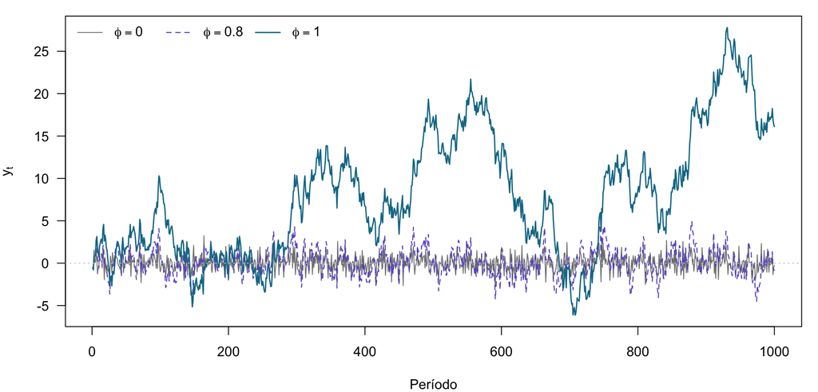

Processos AR(1), $y_t = \phi y_{t-1} + \varepsilon_t$, com: (i) $\phi = 0$ (ruído branco), (ii) $\phi = 0.8$ (processo estacionário) e (iii) $\phi = 1$ (passeio aleatório).

## Operador de Primeira Diferença

A primeira diferença representa a variação de uma variável entre dois períodos consecutivos:

$$\Delta Y_t=Y_t-Y_{t-1}.$$

**Em séries temporais:** pode transformar uma série não estacionária com raiz unitária em uma série fracamente estacionária, sob condições apropriadas.

Por exemplo, em um passeio aleatório:

$$Y_t=Y_{t-1}+\varepsilon_t
\quad\Rightarrow\quad
\Delta Y_t=\varepsilon_t.$$

A série diferenciada será fracamente estacionária se $\varepsilon_t$ também o for.

**Em dados em painel:** a diferença é calculada separadamente para cada unidade:

$$\Delta Y_{it}=Y_{it}-Y_{i,t-1}.$$

Sua aplicação permite eliminar efeitos individuais constantes no tempo, pois $\Delta u_i=u_i-u_i=0$.

## Modelo Autorregressivo em Dados em Painel

Uma extensão do processo AR(1) para dados em painel permite representar a dependência temporal de $Y$ e incorporar a heterogeneidade individual não observada, por meio de um efeito específico de cada unidade, suposto constante ao longo do tempo:

$$Y_{it}=\rho Y_{i,t-1}+u_i+e_{it}.$$

Em que:

- $Y_{i,t-1}$ é o valor da variável para a mesma unidade no período anterior;
- $\rho$ é o coeficiente autorregressivo, que representa a persistência temporal;
- $u_i$ é o efeito individual não observado, constante no tempo, que atua como intercepto específico da unidade;
- $e_{it}$ é o erro idiossincrático, que varia entre unidades e períodos.

**Desafio econométrico:** $u_i$ pode estar correlacionado com $Y_{i,t-1}$. Além disso, eliminar $u_i$ não garante que o regressor defasado seja exógeno.

## Primeiras Diferenças: Modelo em Dois Períodos

Considere o modelo autorregressivo em painel:

$$Y_{it}=\rho Y_{i,t-1}+u_i+e_{it}.$$

**Objetivo:** eliminar o efeito individual não observado $u_i$, que pode estar correlacionado com a variável dependente defasada.

Para uma mesma unidade $i$, escrevemos o modelo em dois períodos consecutivos:

$$\begin{aligned}
\text{Período }t:\quad
Y_{it} &= \rho Y_{i,t-1}+u_i+e_{it},\\[10pt]
\text{Período }t-1:\quad
Y_{i,t-1} &= \rho Y_{i,t-2}+u_i+e_{i,t-1}.
\end{aligned}$$

**Observe:** embora $Y$ e $e$ possam variar entre os períodos, o efeito individual $u_i$ é o mesmo nas duas equações.

**Estratégia:** subtrair a equação do período $t-1$ da equação do período $t$.

## Primeiras Diferenças: Eliminação do Efeito Individual

Subtraindo a equação do período $t-1$ da equação do período $t$:

$$\begin{aligned}
Y_{it}-Y_{i,t-1}
&=(\rho Y_{i,t-1}+u_i+e_{it})\\
&\quad -(\rho Y_{i,t-2}+u_i+e_{i,t-1})\\[8pt]
&=\rho(Y_{i,t-1}-Y_{i,t-2})\\
&\quad +\underbrace{(u_i-u_i)}_{=0}
+(e_{it}-e_{i,t-1}).
\end{aligned}$$

Utilizando a notação de primeiras diferenças:

$$\begin{aligned}
\Delta Y_{it} &= Y_{it}-Y_{i,t-1},\\
\Delta Y_{i,t-1} &= Y_{i,t-1}-Y_{i,t-2},\\
\Delta e_{it} &= e_{it}-e_{i,t-1}.
\end{aligned}$$

Obtemos o modelo em primeiras diferenças:

$$\boxed{\Delta Y_{it}=\rho\Delta Y_{i,t-1}+\Delta e_{it}.}$$

## Endogeneidade: Origem do Problema

Após eliminar o efeito individual por primeiras diferenças, obtivemos:

$$\Delta Y_{it}=\rho\Delta Y_{i,t-1}+\Delta e_{it}.$$

Por que o regressor $\Delta Y_{i,t-1}$ pode estar correlacionado com o erro $\Delta e_{it}$?

Escrevendo a equação diferenciada um período antes, temos o regressor:

$$\begin{aligned}
\Delta Y_{i,t-1}
&=\rho\Delta Y_{i,t-2}+\Delta e_{i,t-1}\\[6pt]
&=\rho\Delta Y_{i,t-2}
+\underbrace{e_{i,t-1}}_{\text{choque em }t-1}
-e_{i,t-2}.
\end{aligned}$$

O erro da equação no período $t$ é:

$$\Delta e_{it}
=e_{it}-\underbrace{e_{i,t-1}}_{\text{mesmo choque}}.$$

**Observe:** o choque $e_{i,t-1}$ aparece tanto no regressor quanto no erro, com sinais opostos.

## Endogeneidade: Efeito de um Choque

Retomando as expressões do slide anterior:

$$\begin{aligned}
\Delta Y_{i,t-1}
&=\rho\Delta Y_{i,t-2}
+\underbrace{e_{i,t-1}}_{\text{choque anterior}}
-e_{i,t-2},\\[8pt]
\Delta e_{it}
&=e_{it}
-\underbrace{e_{i,t-1}}_{\text{mesmo choque}}.
\end{aligned}$$

**Experimento:** suponha que o choque $e_{i,t-1}$ seja uma unidade maior, mantendo os demais termos das expressões inalterados.

| Componente | Como o choque aparece | Variação provocada |
| --- | --- | --- |
| Regressor $\Delta Y_{i,t-1}$ | $+e_{i,t-1}$ | **Aumenta 1 unidade** |
| Erro $\Delta e_{it}$ | $-e_{i,t-1}$ | **Diminui 1 unidade** |

**Interpretação:** uma variação no mesmo choque altera simultaneamente o regressor e o erro, em sentidos opostos.

Essa relação pode gerar correlação entre o regressor e o erro, caracterizando endogeneidade.

## Endogeneidade: Hipóteses e Propriedades

Retomando as expressões do regressor e do erro:

$$\begin{aligned}
\Delta Y_{i,t-1}
&=\rho\Delta Y_{i,t-2}+e_{i,t-1}-e_{i,t-2},\\
\Delta e_{it}
&=e_{it}-e_{i,t-1}.
\end{aligned}$$

**Hipóteses:** para cada unidade $i$, suponha que:

$$\begin{aligned}
E(e_{it}) &= 0,\qquad
\operatorname{Var}(e_{it})=\sigma_e^2>0,\\[6pt]
\operatorname{Cov}(e_{it},e_{is}) &= 0,
\qquad s\neq t,\\[6pt]
\operatorname{Cov}(e_{it},Y_{is}) &= 0,
\qquad s<t.
\end{aligned}$$

Ou seja, os erros têm média zero, variância constante, ausência de correlação serial e são não correlacionados com valores passados de $Y$.

**Propriedades:** $\operatorname{Cov}(aX+bY,Z)=a\operatorname{Cov}(X,Z)+b\operatorname{Cov}(Y,Z)$, aplicável aos dois argumentos; e $\operatorname{Cov}(X,X)=\operatorname{Var}(X)$.

## Endogeneidade: Demonstração da Covariância

$$\begin{aligned}
\operatorname{Cov}(\Delta Y_{i,t-1},\Delta e_{it})
&=\operatorname{Cov}\big(
\rho\Delta Y_{i,t-2}+e_{i,t-1}-e_{i,t-2},
\,e_{it}-e_{i,t-1}\big)\\[10pt]
&=\rho\underbrace{\operatorname{Cov}(\Delta Y_{i,t-2},e_{it})}_{=0}
-\rho\underbrace{\operatorname{Cov}(\Delta Y_{i,t-2},e_{i,t-1})}_{=0}\\[10pt]
&\quad+\underbrace{\operatorname{Cov}(e_{i,t-1},e_{it})}_{=0}
-\underbrace{\operatorname{Var}(e_{i,t-1})}_{=\sigma_e^2}\\[10pt]
&\quad-\underbrace{\operatorname{Cov}(e_{i,t-2},e_{it})}_{=0}
+\underbrace{\operatorname{Cov}(e_{i,t-2},e_{i,t-1})}_{=0}\\[10pt]
&=\boxed{-\sigma_e^2\neq 0}.
\end{aligned}$$

## Resumo

- **AR(1) e persistência:** o valor atual de uma variável depende de seu valor anterior e de um choque aleatório. O coeficiente autorregressivo determina a persistência dos efeitos dos choques.
- **Modelo dinâmico em painel:** incorpora a variável dependente defasada e a heterogeneidade individual não observada, suposta constante no tempo:

  $Y_{it}=\rho Y_{i,t-1}+u_i+e_{it}$.
- **Primeiras diferenças:** a transformação elimina o efeito individual $u_i$, produzindo:

  $\Delta Y_{it}=\rho\Delta Y_{i,t-1}+\Delta e_{it}$.
- Endogeneidade: o regressor e o erro diferenciados compartilham o choque $e_{i,t-1}$. Sob as hipóteses adotadas, sua covariância é $-\sigma_e^2\neq 0$.

**Conclusão:** a primeira diferença elimina $u_i$, mas não resolve a endogeneidade. O MQO aplicado à equação diferenciada não é consistente nas condições estudadas.

**Próximo tópico:** Método dos Momentos.

Visão Geral do Método dos Momentos

## Método dos momentos

O método dos momentos (MM)<sup>1</sup> permite construir estimadores a partir de relações populacionais entre os parâmetros de interesse e a amostra.

Sua lógica é:

1. **População:** estabelecer relações envolvendo valores esperados (*momentos populacionais*).
2. **Amostra:** construir as contrapartidas empíricas dessas relações (*momentos amostrais*).
3. **Estimação:** resolver as equações para obter os estimadores.

Em muitos problemas, isso dispensa a especificação completa da distribuição de probabilidade dos dados.

Entretanto, o método exige condições de momento válidas e identificação dos parâmetros.

[^1]: O Método dos momentos foi desenvolvido em 1894 por Karl Pearson, um dos pais da estatística matemática.

## Momentos de uma distribuição

Na estatística, os momentos são esperanças matemáticas que descrevem características de uma distribuição de probabilidade (ou de uma população).

Para uma variável aleatória $Y$, com média $\mu=E[Y]$, definimos os momentos de ordem $r=1,2,\ldots$:

$$\begin{aligned}
\text{Momento não centrado:} \quad & E[Y^r] \\[8pt]
\text{Momento centrado:} \quad & E[(Y-\mu)^r]
\end{aligned}$$

**Exemplos:**

- **Média:** primeiro momento não centrado, $E[Y]$.
- **Variância:** segundo momento centrado, $E[(Y-\mu)^2]$.
- **Covariância:** momento centrado conjunto de duas variáveis aleatórias.

As definições pressupõem a existência das respectivas esperanças.

No Método dos Momentos MM e no Método Generalizado dos Momentos (GMM), também utilizamos esperanças de funções mais gerais dos dados e parâmetros.

## Condições de momento

Uma condição de momento é uma restrição populacional expressa por uma esperança matemática igual a zero.

Por exemplo, a definição da média populacional pode ser escrita como:

$$\mu_0=E[Y_i]
\quad\Longleftrightarrow\quad
E[Y_i-\mu_0]=0.$$

Em econometria, condições de momento também podem decorrer de hipóteses sobre o modelo.

Por exemplo, em um modelo de regressão linear, podemos assumir que o erro $e_i$ tem média zero e não está correlacionado com a variável explicativa $x_i$:

$$E(e_i)=0,
\qquad
\operatorname{Cov}(x_i,e_i)=0.$$

Essas hipóteses serão utilizadas para construir as condições de momento que permitem obter os estimadores de mínimos quadrados ordinários (MQO).

**Importante:** ausência de correlação não implica independência entre as variáveis.

## Momentos amostrais

Os momentos de uma distribuição são quantidades populacionais, geralmente desconhecidas.

Com uma amostra aleatória $Y_1,\ldots,Y_n$, podemos calcular os momentos amostrais correspondentes.

$$\begin{aligned}
\text{Primeiro momento:}\quad
E[Y_i]
&\longleftrightarrow
\frac{1}{n}\sum_{i=1}^{n}Y_i=\overline Y
\\[12pt]
\text{Segundo momento não centrado:}\quad
E[Y_i^2]
&\longleftrightarrow
\frac{1}{n}\sum_{i=1}^{n}Y_i^2
\end{aligned}$$

Os momentos amostrais são calculados a partir dos dados e, em geral, não coincidem exatamente com os momentos populacionais em uma amostra finita.

O método dos momentos utiliza essas correspondências para construir estimadores de parâmetros desconhecidos.

## Média populacional

Considere uma amostra aleatória de cinco observações:

$$(y_1,y_2,y_3,y_4,y_5)=(5,10,9,14,7).$$

Queremos estimar a média populacional da qual essas observações foram extraídas.

Nosso parâmetro de interesse é:

$$\mu_0=E[Y_i].$$

Embora conheçamos os valores observados, a média populacional $\mu_0$ é desconhecida.

Como podemos utilizar o primeiro momento amostral para estimá-la?

## Estimador MM da média

O primeiro momento populacional é: $E[Y_i]=\mu$.

Seu correspondente amostral é: $\overline Y=\frac{1}{n}\sum_{i=1}^{n}Y_i$.

Pelo método dos momentos, igualamos a expressão do primeiro momento populacional, em função de um valor candidato $\mu$, ao primeiro momento amostral:

$$E[Y_i] = \mu = \frac{1}{n}\sum_{i=1}^{n}Y_i$$

Dessa igualdade, obtemos diretamente o estimador MM:

$$\boxed{
\widehat{\mu}_{MM}
=
\frac{1}{n}\sum_{i=1}^{n}Y_i
}$$

Portanto, o estimador MM da média populacional é a própria média amostral:

$$\widehat{\mu}_{MM}=\overline Y.$$

## Estimativa da média

Aplicando o estimador às cinco observações:

$$\overline y
=\frac{5+10+9+14+7}{5}
=\boxed{9}.$$

Observe a distinção:

- **Parâmetro:** $\mu_0=E[Y_i]$ — média populacional, fixa e desconhecida.
- **Estimador:** $\widehat{\mu}_{MM}=\overline Y$ — função das observações aleatórias.
- **Estimativa:** $\overline y=9$ — resultado para esta amostra específica.

A estimativa é 9, mas a verdadeira média populacional permanece desconhecida.

## Estimador do MM

### Estimador de um parâmetro da Distribuição uniforme contínua

Considere uma amostra aleatória de uma distribuição uniforme contínua:

$$X_i\sim U(0,\theta), \qquad \theta>0.$$

Queremos estimar o parâmetro desconhecido $\theta_0$, que representa o limite superior da distribuição.

O primeiro momento populacional (média) desta distribuição uniforme é:

$$E[X_i] = \frac{0 + \theta}{2} =\frac{\theta}{2}.$$

O primeiro momento amostral é $\overline X$.

## Estimador MM

### Estimador de um parâmetro da Distribuição uniforme contínua

**Igualando os momentos correspondentes:**

$$\begin{aligned}
\frac{\widehat{\theta}_{MM}}{2}
&=\overline X \\[10pt]
\widehat{\theta}_{MM}
&=2\overline X
\end{aligned}$$

Portanto, o estimador do Método dos Momentos (MM) de $\theta$ é duas vezes a média amostral.

## MQO: modelo de regressão simples

O estimador de mínimos quadrados ordinários (MQO) também pode ser obtido pelo método dos momentos (MM).

Considere uma amostra aleatória de $N$ observações e o modelo:

$$y_i=\beta_1+\beta_2x_i+e_i,
\qquad i=1,\ldots,N.$$

- $y_i$: variável dependente;
- $x_i$: variável explicativa;
- $\beta_1$ e $\beta_2$: parâmetros populacionais desconhecidos;
- $e_i$: termo de erro.

Admitimos as seguintes hipóteses:

$$\boxed{
E(e_i)=0,
\qquad
\operatorname{Cov}(x_i,e_i)=0.
}$$

Utilizaremos essas hipóteses para construir duas condições de momento e obter os estimadores de $\beta_1$ e $\beta_2$.

## MQO: condições de momento populacionais

No modelo de regressão linear simples, podemos escrever o erro como:

$$e_i=y_i-\beta_1-\beta_2x_i.$$

**Primeira condição:** como $E(e_i)=0$, temos:

$$\boxed{
E(y_i-\beta_1-\beta_2x_i)=0.
}$$

**Segunda condição:** sabemos que:

$$\operatorname{Cov}(x_i,e_i)
=E(x_ie_i)-E(x_i)E(e_i).$$

Como $E(e_i)=0$ e $\operatorname{Cov}(x_i,e_i)=0$, segue que $E(x_ie_i)=0$. Portanto:

$$\boxed{
E[x_i(y_i-\beta_1-\beta_2x_i)]=0.
}$$

Obtivemos duas condições de momento populacionais para os dois parâmetros desconhecidos.

## MQO: condições de momento amostrais

As duas condições de momento populacionais são:

$$\begin{aligned}
E(y_i-\beta_1-\beta_2x_i)&=0,\\[8pt]
E[x_i(y_i-\beta_1-\beta_2x_i)]&=0.
\end{aligned}$$

Pela Lei dos Grandes Números, sob amostragem aleatória e condições apropriadas, os momentos amostrais convergem para os correspondentes momentos populacionais.

No MM, substituímos as esperanças pelas médias amostrais e resolvemos o sistema de equações para determinar os estimadores dos parâmetros.

Igualando os momentos amostrais a zero:

$$\boxed{
\begin{aligned}
\frac{1}{N}\sum_{i=1}^{N}
(y_i-\beta_1-\beta_2x_i)&=0,\\[14pt]
\frac{1}{N}\sum_{i=1}^{N}
x_i(y_i-\beta_1-\beta_2x_i)&=0.
\end{aligned}
}$$

Temos agora um sistema de duas equações amostrais com duas incógnitas, $\beta_1$ e $\beta_2$.

## MQO: primeira equação amostral

Começamos pela primeira condição de momento amostral:

$$\frac{1}{N}\sum_{i=1}^{N}(y_i-\beta_1-\beta_2x_i)=0.$$

Multiplicando ambos os lados por $N$ e desenvolvendo o somatório:

$$\sum_{i=1}^{N}y_i
-N\beta_1
-\beta_2\sum_{i=1}^{N}x_i=0.$$

Dividindo por $N$ e utilizando as médias amostrais $\overline y$ e $\overline x$:

$$\overline y-\beta_1-\beta_2\overline x=0.$$

Isolando $\beta_1$:

$$\boxed{
\hat \beta_1 =\overline y - \hat \beta_2 \overline x.
}$$

O estimador do intercepto depende do estimador da inclinação, $\beta_2$, que ainda precisamos determinar.

## MQO: segunda equação amostral

Partimos da segunda condição de momento amostral:

$$\frac{1}{N}\sum_{i=1}^{N}
x_i(y_i-\beta_1-\beta_2x_i)=0.$$

Multiplicando por $N$ e desenvolvendo o somatório:

$$\sum_{i=1}^{N}x_iy_i
-\beta_1\sum_{i=1}^{N}x_i
-\beta_2\sum_{i=1}^{N}x_i^2=0.$$

Na primeira equação, obtivemos: $\beta_1=\overline y-\beta_2\overline x.$

Substituindo essa expressão:

$$\sum_{i=1}^{N}x_iy_i
-(\overline y-\beta_2\overline x)\sum_{i=1}^{N}x_i
- \beta_2\sum_{i=1}^{N}x_i^2=0.$$

Agora temos uma equação que contém apenas **um parâmetro desconhecido: $\beta_2$**.

## MQO: resolução para o estimador da inclinação

Desenvolvendo a expressão anterior:

$$0=\sum_{i=1}^{N}x_iy_i
-\overline y\sum_{i=1}^{N}x_i
+\beta_2\overline x\sum_{i=1}^{N}x_i
-\beta_2\sum_{i=1}^{N}x_i^2.$$

Agrupando os termos que contêm $\beta_2$:

$$\beta_2\left(
\sum_{i=1}^{N}x_i^2
-\overline x\sum_{i=1}^{N}x_i
\right)
=\sum_{i=1}^{N}x_iy_i - \overline y\sum_{i=1}^{N}x_i.$$

Como $\sum_{i=1}^{N}x_i=N\overline x$, obtemos:

$$\beta_2\left(
\sum_{i=1}^{N}x_i^2-N\overline x^2
\right)
=
\sum_{i=1}^{N}x_iy_i
-N\overline x\overline y.$$

Finalmente, isolando $\beta_2$:

$$\boxed{
\hat \beta_2=
\frac{
\sum_{i=1}^{N}x_iy_i-N\overline x\overline y
}{
\sum_{i=1}^{N}x_i^2-N\overline x^2
}.
}$$

## MQO: somatórios em desvios das médias

Podemos reescrever o estimador $\beta_2$ utilizando os desvios das observações em relação às respectivas médias amostrais<sup>1</sup>.

**Numerador:**

$$\begin{aligned}
&\sum_{i=1}^{N}
(x_i-\overline x)(y_i-\overline y)
=\sum_{i=1}^{N}x_iy_i
-\overline y\sum_{i=1}^{N}x_i
-\overline x\sum_{i=1}^{N}y_i
+N\overline x\overline y\\[6pt]
&=\sum_{i=1}^{N}x_iy_i
-N\overline x\overline y.
\end{aligned}$$

**Denominador:**

$$\begin{aligned}
&\sum_{i=1}^{N}(x_i-\overline x)^2
=\sum_{i=1}^{N}x_i^2
-2\overline x\sum_{i=1}^{N}x_i
+N\overline x^2\\[6pt]
&=\sum_{i=1}^{N}x_i^2-N\overline x^2.
\end{aligned}$$

[^2]: Essas identidades permitem expressar $\beta_2$ na forma usual do estimador MQO.

## MQO: estimadores pelo método dos momentos

Substituindo as expressões obtidas para o numerador e o denominador:

$$\boxed{
\hat \beta_2 =
\frac{
\sum_{i=1}^{N}
(x_i-\overline x)(y_i-\overline y)
}{
\sum_{i=1}^{N}
(x_i-\overline x)^2
}.
}$$

Retomando o resultado da primeira equação amostral:

$$\boxed{
\hat \beta_1 = \overline y - \hat \beta_2 \overline x.
}$$

Essas são exatamente as fórmulas dos estimadores de mínimos quadrados ordinários (MQO).<sup>1</sup>

**Conclusão:** o método dos momentos permite obter os estimadores MQO a partir das condições $E(e_i)=0$ e $\operatorname{Cov}(x_i,e_i)=0$.

Sob essas hipóteses e as demais condições apropriadas, os estimadores são consistentes em grandes amostras.

[^3]: Para determinar $\beta_2$, é necessário que a variável explicativa apresente variação na amostra: $\sum_{i=1}^{N}(x_i-\overline x)^2>0.$

## Método dos momentos

### Resumo

O método dos momentos (MM) constrói estimadores a partir de relações entre os momentos populacionais desconhecidos e os momentos amostrais correspondentes.

Nos exemplos estudados:

- Média populacional: o estimador MM é a média amostral.
- **Distribuição uniforme:** o estimador MM é duas vezes a média amostral.
- **Regressão linear:** as condições de momento conduzem aos estimadores usuais de MQO.

Vimos também que podemos obter um estimador MM substituindo momentos populacionais pelos amostrais ou resolvendo diretamente as condições de momento amostrais.

**Uma vantagem importante:** o MM não exige a especificação completa da distribuição de probabilidade dos dados, diferentemente da abordagem usual de máxima verossimilhança.

## Limitações do Método dos Momentos

O Método dos Momentos exige:

- Condições de momento válidas, fundamentadas nas características da população ou nas hipóteses do modelo.
- Identificação dos parâmetros, para que as condições populacionais determinem seus valores de maneira única.
- Soluções apropriadas para as equações de momento amostrais.

Na derivação dos estimadores MQO pelo método dos momentos, utilizamos $E(e_i)=0$ e $\operatorname{Cov}(x_i,e_i)=0$.

Entretanto, se $x_i$ for endógena, teremos: $\boxed{\operatorname{Cov}(x_i,e_i)\neq 0.}$

Nesse caso, uma das condições de momento utilizadas para obter os estimadores MQO deixa de ser válida, e esses estimadores são, em geral, inconsistentes.

Como estimar os parâmetros do modelo quando a variável explicativa está correlacionada com o erro?

**Próximo tópico:** Variáveis Instrumentais.

Visão Geral das Variáveis Instrumentais

## Variáveis instrumentais

### Motivação e estratégia

Considere o modelo de regressão com $x_i$ endógena:

$$y_i=\beta_1+\beta_2x_i+e_i,
\qquad \operatorname{Cov}(x_i,e_i)\neq 0.$$

**Problema:** como $x_i$ está correlacionada com o erro, a condição de momento utilizada pelo MQO não é válida. Precisamos de outra fonte de informação para estimar consistentemente $\beta_2$.

**Estratégia:** procurar uma variável auxiliar, $z_i$, que esteja associada a $x_i$, mas que não esteja correlacionada com o erro $e_i$.

**Ideia:** utilizar a parcela da variação de $x_i$ associada a $z_i$ para identificar o **coeficiente de $x_i$**, e não o efeito de $z_i$ sobre $y_i$.

Pergunta: quais requisitos $z_i$ deve satisfazer para que essa estratégia seja válida?

## Requisitos de uma variável instrumental

Considere uma variável $z_i$ que não pertence à equação estrutural como variável explicativa. Para utilizá-la como instrumento de $x_i$, precisamos de três requisitos:

- IV1 — Exclusão: $z_i$ não afeta $y_i$ diretamente nem por outros caminhos que não passem por $x_i$.
- IV2 — Exogeneidade: $z_i$ não está correlacionada com o erro do modelo, isto é, $\operatorname{Cov}(z_i,e_i)=0$.
- IV3 — Relevância: $z_i$ está correlacionada com a variável endógena $x_i$, isto é, $\operatorname{Cov}(z_i,x_i)\neq 0$.

Uma variável que satisfaz esses requisitos pode ser utilizada como instrumento válido e relevante para $x_i$.

**Atenção:** exclusão e exogeneidade exigem fundamentação econômica; não podem ser estabelecidas apenas pelas correlações observadas nos dados.

## Serviço militar e rendimentos

Em Angrist (1990), a pergunta é: qual é o efeito causal do serviço militar sobre os rendimentos civis posteriores?

Considere uma representação simplificada do modelo:

$$Rendimentos_i=\beta_0+\beta_1Veterano_i+\varepsilon_i,$$

em que $Veterano_i=1$ se o indivíduo prestou serviço militar e $0$ caso contrário.

Nesse modelo, MQO compara os rendimentos médios de **veteranos e não veteranos**.

Entretanto, esses grupos podem diferir previamente em saúde, aptidão e condições familiares, fatores que também afetam rendimentos.

Assim, a diferença observada pode combinar o efeito do serviço militar com o viés de seleção.

**Desafio:** como identificar o efeito causal sem depender apenas dessa comparação direta?

## Sorteio, elegibilidade e serviço efetivo

Durante a Guerra do Vietnã, um sorteio de datas de nascimento estabelecia a prioridade de convocação para o serviço militar.

O número sorteado, combinado com um limite de convocação, determinava a elegibilidade ao recrutamento obrigatório.

Entretanto, **ser elegível não significava necessariamente servir**: alguns elegíveis não prestaram serviço, enquanto alguns não elegíveis ingressaram voluntariamente.

No estudo de Angrist (1990):

- Instrumento $z_i$: elegibilidade à convocação, determinada pelo sorteio.
- Regressor endógeno $x_i$: serviço militar efetivamente prestado.
- **Resultado $y_i$:** rendimentos civis posteriores.

**Ponto central:** o sorteio alterava a probabilidade de servir, mas não determinava diretamente quem prestaria serviço militar.

## VI: nova condição de momento

Se uma variável instrumental com essas características existe, podemos utilizá-la para formar uma nova condição de momento.

Como $\operatorname{Cov}(z_i,e_i)=0$ e $E(e_i)=0$, temos:

$$\boxed{E(z_ie_i)=0.}$$

Substituindo $e_i=y_i-\beta_1-\beta_2x_i$:

$$\boxed{
E[z_i(y_i-\beta_1-\beta_2x_i)]=0.
}$$

Essa condição de momento, baseada no instrumento $z_i$, substitui a condição inválida $E(x_ie_i)=0$, utilizada anteriormente na derivação do MQO.

## VI: condições de momento populacionais

A condição de momento construída com o instrumento $z_i$ permite substituir aquela que deixou de ser válida devido à endogeneidade de $x_i$.

Mantemos a primeira condição de momento, derivada de $E(e_i)=0$:

$$E(y_i-\beta_1-\beta_2x_i)=0.$$

Utilizamos a nova condição de momento, derivada de $E(z_ie_i)=0$:

$$E[z_i(y_i-\beta_1-\beta_2x_i)]=0.$$

Temos, portanto, duas condições de momento populacionais para os dois parâmetros desconhecidos, $\beta_1$ e $\beta_2$.

## VI: condições de momento amostrais

Pela Lei dos Grandes Números, sob amostragem aleatória e condições apropriadas, os momentos amostrais convergem para os correspondentes momentos populacionais.

Pelo Método dos Momentos, igualamos as condições amostrais a zero:

$$\boxed{
\begin{aligned}
\frac{1}{N}\sum_{i=1}^{N}
(y_i-\beta_1-\beta_2x_i)&=0,\\[12pt]
\frac{1}{N}\sum_{i=1}^{N}
z_i(y_i-\beta_1-\beta_2x_i)&=0.
\end{aligned}
}$$

Temos novamente duas equações com duas incógnitas, $\beta_1$ e $\beta_2$.

Nessas equações, os parâmetros são tratados como incógnitas do sistema amostral. Suas soluções serão os estimadores VI.

## VI: resolução das equações amostrais

A primeira condição de momento amostral, como na derivação do MQO, fornece:

$$\boxed{\beta_1=\overline y-\beta_2\overline x.}$$

Partimos agora da segunda condição de momento amostral:

$$\frac{1}{N}\sum_{i=1}^{N}z_i(y_i-\beta_1-\beta_2x_i)=0.$$

Multiplicando por $N$ e desenvolvendo o somatório:

$$\sum_{i=1}^{N}z_iy_i
-\beta_1\sum_{i=1}^{N}z_i
-\beta_2\sum_{i=1}^{N}z_ix_i=0.$$

Substituindo $\beta_1=\overline y-\beta_2\overline x$:

$$\sum_{i=1}^{N}z_iy_i
-(\overline y-\beta_2\overline x)\sum_{i=1}^{N}z_i
-\beta_2\sum_{i=1}^{N}z_ix_i=0.$$

## VI: resolução para o estimador da inclinação

Desenvolvendo a expressão anterior:

$$0=\sum_{i=1}^{N}z_iy_i
-\overline y\sum_{i=1}^{N}z_i
+\beta_2\overline x\sum_{i=1}^{N}z_i
-\beta_2\sum_{i=1}^{N}z_ix_i.$$

Agrupando os termos que contêm $\beta_2$:

$$\beta_2\left(
\sum_{i=1}^{N}z_ix_i-\overline x\sum_{i=1}^{N}z_i
\right)
=
\sum_{i=1}^{N}z_iy_i-\overline y\sum_{i=1}^{N}z_i.$$

Como $\sum_{i=1}^{N}z_i=N\overline z$, obtemos:

$$\beta_2\left(
\sum_{i=1}^{N}z_ix_i-N\overline z\overline x
\right)
=
\sum_{i=1}^{N}z_iy_i-N\overline z\overline y.$$

Isolando $\beta_2$:

$$\boxed{
\beta_2=
\frac{\sum_{i=1}^{N}z_iy_i-N\overline z\overline y}
{\sum_{i=1}^{N}z_ix_i-N\overline z\overline x}.
}$$

## VI: somatórios em desvios das médias

Podemos reescrever a expressão anterior utilizando os desvios em relação às médias amostrais, como fizemos na derivação do MQO.

**Numerador:**

$$\sum_{i=1}^{N}(z_i-\overline z)(y_i-\overline y)
=
\sum_{i=1}^{N}z_iy_i-N\overline z\overline y.$$

**Denominador:**

$$\sum_{i=1}^{N}(z_i-\overline z)(x_i-\overline x)
=
\sum_{i=1}^{N}z_ix_i-N\overline z\overline x.$$

Essas identidades permitem obter a expressão usual do estimador VI.

## VI: estimadores pelo método dos momentos

Substituindo as expressões obtidas para o numerador e o denominador:

$$\boxed{
\widehat{\beta}_{2,\mathrm{VI}}
=
\frac{
\sum_{i=1}^{N}(z_i-\overline z)(y_i-\overline y)
}{
\sum_{i=1}^{N}(z_i-\overline z)(x_i-\overline x)
}.
}$$

Retomando o resultado da primeira equação amostral:

$$\boxed{
\widehat{\beta}_{1,\mathrm{VI}}
=\overline y-\widehat{\beta}_{2,\mathrm{VI}}\overline x.
}$$

Essas são as expressões dos estimadores por variáveis instrumentais (VI) obtidos pelo Método dos Momentos.

Para determinar $\widehat{\beta}_{2,\mathrm{VI}}$, o denominador deve ser diferente de zero.<sup>1</sup>

[^4]: Na população, a identificação exige $\operatorname{Cov}(z_i,x_i)\neq 0$, conforme a condição de relevância do instrumento.

## VI: propriedades em grandes amostras

Se o instrumento satisfaz as condições **IV1, IV2 e IV3**, sob as demais hipóteses apropriadas, os estimadores VI são consistentes.

Isso significa que, quando o tamanho da amostra aumenta, os estimadores convergem em probabilidade para os parâmetros populacionais:

$$\boxed{
\widehat{\beta}_{1,\mathrm{VI}}\xrightarrow{p}\beta_1,
\qquad
\widehat{\beta}_{2,\mathrm{VI}}\xrightarrow{p}\beta_2.
}$$

Além disso, em grandes amostras, os estimadores VI apresentam distribuição aproximadamente normal.

Para o estimador da inclinação:

$$\widehat{\beta}_{2,\mathrm{VI}}
\overset{a}{\sim}
N\left(\beta_2,
\operatorname{Var}(\widehat{\beta}_{2,\mathrm{VI}})\right).$$

Essa propriedade fundamenta a construção de intervalos de confiança e testes de hipóteses, desde que a variância do estimador seja adequadamente estimada.

## VI: Mínimos Quadrados em Dois Estágios (MQ2E)

Uma forma alternativa de calcular os estimadores VI é utilizar duas regressões por MQO, procedimento denominado Mínimos Quadrados em Dois Estágios (MQ2E).

Essa abordagem também permite estender a estimação VI a modelos mais gerais.

**Primeiro estágio:** regredimos a variável endógena $x_i$ sobre o instrumento $z_i$:

$$x_i=\gamma_1+\theta_1z_i+v_i.$$

Estimamos essa equação por MQO e obtemos os valores ajustados:

$$\boxed{\widehat{x}_i=\widehat{\gamma}_1+\widehat{\theta}_1z_i.}$$

**Segundo estágio:** substituímos $x_i$ por $\widehat{x}_i$ na regressão:

$$\boxed{y_i=\beta_1+\beta_2\widehat{x}_i+e_i^*.}$$

Estimamos essa segunda regressão por MQO.

## VI: condições de momento excedentes

Na regressão linear simples, utilizamos um instrumento para obter duas condições de momento e estimar dois parâmetros, $\beta_1$ e $\beta_2$.

Suponha agora que existam dois instrumentos válidos, $z_{1i}$ e $z_{2i}$, que satisfaçam as condições IV1, IV2 e IV3. Cada instrumento fornece uma condição de momento:

$$E(z_{1i}e_i)=0
\qquad\text{e}\qquad
E(z_{2i}e_i)=0.$$

Juntamente com $E(e_i)=0$, obtemos três condições de momento amostrais:

$$\boxed{
\begin{aligned}
\frac{1}{N}\sum_{i=1}^{N}
(y_i-\beta_1-\beta_2x_i)&=0,\\[10pt]
\frac{1}{N}\sum_{i=1}^{N}
z_{1i}(y_i-\beta_1-\beta_2x_i)&=0,\\[10pt]
\frac{1}{N}\sum_{i=1}^{N}
z_{2i}(y_i-\beta_1-\beta_2x_i)&=0.
\end{aligned}
}$$

## VI: condições de momento excedentes

**Problema:**

- Temos três equações para apenas duas incógnitas.
- Em geral, não existe uma solução que satisfaça simultaneamente todas as condições amostrais.

Poderíamos descartar um dos instrumentos e utilizar apenas duas condições de momento.

Entretanto, é possível aproveitar as informações dos dois instrumentos utilizando Minímos Quadrados em Dois Estágios (MQ2E).

## VI em regressão múltipla

Considere a seguinte equação estrutural:

$$y_i=\beta_0+\beta_1x_i+\gamma w_i+e_i.$$

**Variáveis explicativas:**

- **$x_i$:** variável endógena, correlacionada com o erro $e_i$.
- **$w_i$:** variável exógena, utilizada como controle.

Na estimação por VI, distinguimos:

- **Instrumentos incluídos:** a constante e $w_i$, que pertencem à própria equação estrutural.
- **Instrumentos externos:** $z_{1i}$ e $z_{2i}$, que não pertencem à equação estrutural e devem satisfazer os requisitos de exclusão, exogeneidade e relevância.

O MQ2E utiliza os instrumentos incluídos e externos para estimar o coeficiente da variável endógena $x_i$, controlando por $w_i$.

## MQ2E em regressão múltipla

Considere o modelo $y_i=\beta_0+\beta_1x_i+\gamma w_i+e_i$, com $x_i$ endógena, $w_i$ exógena e dois instrumentos externos, $z_{1i}$ e $z_{2i}$.

**Primeiro estágio:** regredimos $x_i$ sobre os dois instrumentos externos e o controle exógeno $w_i$:

$$x_i=\pi_0+\pi_1z_{1i}+\pi_2z_{2i}+\pi_3w_i+v_i.$$

Estimando por MQO, obtemos os valores ajustados:

$$\widehat{x}_i=
\widehat{\pi}_0+\widehat{\pi}_1z_{1i}
+\widehat{\pi}_2z_{2i}+\widehat{\pi}_3w_i.$$

**Segundo estágio:** substituímos $x_i$ por $\widehat{x}_i$ e estimamos por MQO:

$$\boxed{
y_i=\beta_0+\beta_1\widehat{x}_i+\gamma w_i+e_i^*.
}$$

**Resultado:** o MQ2E combina as informações dos dois instrumentos externos para estimar o coeficiente de $x_i$, sem exigir que todas as condições de momento amostrais sejam simultaneamente iguais a zero.

Os erros-padrão devem ser calculados pelo procedimento de inferência próprio do MQ2E, e não diretamente pela segunda regressão MQO isolada.

## Diagnósticos da especificação VI

Considere o modelo com regressor endógeno $x_i$, controle exógeno $w_i$ e instrumentos externos $z_{1i},\ldots,z_{Li}$:

$$y_i=\beta_0+\beta_1x_i+\delta w_i+\varepsilon_i.$$

Três perguntas orientam a avaliação da especificação:

1. **Relevância — Teste F:** os instrumentos explicam $x_i$, após considerar $w_i$? Teste da relevância conjunta dos instrumentos.
2. **Endogeneidade — Wu–Hausman:** há evidência de correlação entre $x_i$ e o erro estrutural? Teste de endogeneidade de $x_i$
3. **Sobreidentificação — Sargan:** as condições de momento excedentes são compatíveis com o modelo? Teste de exogeneidade dos intrumentos

O teste de Sargan exige **mais instrumentos externos do que regressores endógenos**.

## Relevância dos instrumentos

### Hipóteses do teste F

Considere o **primeiro estágio**, com $L$ instrumentos externos e um controle exógeno:

$$x_i=\gamma_0+\sum_{\ell=1}^{L}\gamma_\ell z_{\ell i}
+\gamma_w w_i+v_i.$$

Queremos verificar se os instrumentos contribuem **conjuntamente** para explicar $x_i$, após considerar $w_i$. Testamos as hipóteses:

$$\begin{aligned}
H_0 &: \gamma_1=\gamma_2=\cdots=\gamma_L=0,\\[8pt]
H_1 &: \text{pelo menos um }\gamma_\ell\neq0.
\end{aligned}$$

- **Sob $H_0$:** os instrumentos não acrescentam poder explicativo linear ao primeiro estágio .
- **Sob $H_1$:** pelo menos um instrumento contribui para explicar $x_i$, após considerar $w_i$ (isto é, pelo menos um dos instrumentos é relvante?).

O teste F avalia os coeficientes dos instrumentos **conjuntamente**, mantendo o controle na regressão.

## Relevância dos instrumentos

### Estatística F

Comparamos o primeiro estágio **restrito** (sem os instrumentos externos) ao **completo** (com os instrumentos), mantendo o controle exógeno em ambos.

A estatística do teste é:

$$\boxed{
F=\frac{(SQR_R-SQR_U)/L}{SQR_U/(N-K_1)}.
}$$

- $SQR_R$ e $SQR_U$: somas dos quadrados dos resíduos dos modelos restrito e completo.
- $L$: número de instrumentos externos testados.
- $N$: tamanho amostral; $K_1$: número de coeficientes do primeiro estágio completo, incluindo a constante.

Sob $H_0$ e as hipóteses clássicas, $F\sim F_{L,N-K_1}$.

- **Significância:** $p<0{,}05$ indica rejeição de $H_0$.
- **Força instrumental:** $F>10$ é uma referência prática convencional, não uma garantia de instrumentos fortes.

## Teste de Wu–Hausman

### Hipóteses de exogeneidade

Se o regressor $x_i$ for exógeno, **precisamos utilizar VI em vez de MQO?**

Supondo instrumentos válidos, o teste de Wu–Hausman examina as hipóteses:

$$\begin{aligned}
H_0 &: \operatorname{Cov}(x_i,\varepsilon_i)=0,\\[8pt]
H_1 &: \operatorname{Cov}(x_i,\varepsilon_i)\neq0.
\end{aligned}$$

- **Sob $H_0$:** $x_i$ é exógeno. MQO e VI são consistentes, e a diferença entre os estimadores converge para zero.
- **Sob $H_1$:** $x_i$ é endógeno. MQO é inconsistente, enquanto VI permanece consistente.

A rejeição de $H_0$ fornece evidência de **endogeneidade**.

## Teste de Wu–Hausman

### Regressão auxiliar e hipótese testada

Queremos testar se $x_i$ está correlacionado com $\varepsilon_i$, mas **o erro estrutural não é observado**.

Com instrumentos e controle exógenos, essa possível correlação está associada à parte de $x_i$ não explicada no primeiro estágio.

Estimamos esse componente pelos resíduos $\widehat v_i=x_i-\widehat x_i$ e os incluímos em uma **regressão auxiliar por MQO**:

$$y_i=\beta_0+\beta_1x_i+\delta w_i
+\rho\widehat v_i+u_i.$$

Testamos o coeficiente dos resíduos:

$$\boxed{
H_0:\rho=0\qquad\text{contra}\qquad H_1:\rho\neq0.
}$$

A rejeição de $H_0$ fornece evidência de endogeneidade, pressupondo instrumentos válidos.

## Teste de Wu–Hausman

### Estatística e interpretação

Na regressão auxiliar, testamos $H_0:\rho=0$ utilizando a estatística:

$$t=\frac{\widehat\rho}
{\operatorname{se}(\widehat\rho)},
\qquad
\boxed{F=t^2.}$$

Como testamos **uma única restrição**, os testes $t$ bilateral e $F$ são equivalentes na inferência convencional.

Sob as hipóteses clássicas, $F\sim F_{1,N-K_A}$ sob $H_0$, sendo $K_A$ o número de coeficientes da regressão auxiliar.

**Decisão ao nível de significância de 5%:**

- **$p<0{,}05$:** rejeitamos $H_0$; há evidência de endogeneidade de $x_i$.
- **$p\geq0{,}05$:** não rejeitamos $H_0$; não há evidência estatística suficiente de endogeneidade.

A interpretação pressupõe **instrumentos válidos**. Não rejeitar $H_0$ não comprova exogeneidade.

## Teste de Sargan

### Hipóteses de sobreidentificação

Com uma variável endógena e $L>1$ instrumentos externos, o teste de Sargan utiliza as **$L-1$ restrições de sobreidentificação** para avaliar a **exogeneidade conjunta dos instrumentos**.

Instrumentos exógenos não estão correlacionados com o erro estrutural. Suas condições de momento são:

$$E(z_{1i}\varepsilon_i)
=E(z_{2i}\varepsilon_i)
=\cdots=E(z_{Li}\varepsilon_i)=0.$$

O teste de Sargan examina as hipóteses:

- **$H_0$:** todos os instrumentos externos são exógenos, isto é, não estão correlacionados com o erro estrutural.
- **$H_1$:** pelo menos um instrumento externo está correlacionado com o erro estrutural, isto é, é endógeno

## Teste de Sargan

### Regressão auxiliar

Queremos examinar as condições de momento dos instrumentos, mas **o erro estrutural não é observado**.

Primeiro, calculamos os **resíduos estruturais** utilizando os coeficientes VI/MQ2E e o regressor observado $x_i$:

$$\widehat\varepsilon_i
=y_i-\widehat\beta_{0,\mathrm{VI}}
-\widehat\beta_{1,\mathrm{VI}}x_i
-\widehat\delta_{\mathrm{VI}}w_i.$$

Depois, regredimos esses resíduos sobre **todos os instrumentos externos e controles exógenos**:

$$\widehat\varepsilon_i
=a_0+a_ww_i+\sum_{\ell=1}^{L}a_\ell z_{\ell i}+r_i.$$

Se as condições de momento são válidas, não esperamos uma associação sistemática entre os instrumentos e o erro estrutural.

O teste de Sargan utiliza o **$R^2$ dessa regressão auxiliar** para avaliar as restrições de sobreidentificação.

## Teste de Sargan

### Estatística e interpretação

A estatística de Sargan utiliza o $R^2$ da **regressão auxiliar** apresentada anteriormente: $\boxed{J=NR^2.}$

- $N$: tamanho da amostra.
- $R^2$: coeficiente de determinação da regressão auxiliar.

Sob $H_0$ e as condições convencionais do teste:

$$J\xrightarrow{d}\chi^2_{L-1}.$$

Com uma variável endógena e $L$ instrumentos externos, os **$L-1$ graus de liberdade** correspondem às restrições de sobreidentificação.

## Interpretação dos diagnósticos VI

Os três testes avaliam **aspectos distintos** da especificação por VI/MQ2E:

| Teste | O que investiga? | Rejeição de $H_0$ a 5% |
| --- | --- | --- |
| **F do primeiro estágio** | Os instrumentos externos contribuem conjuntamente para explicar $x_i$, após considerar os controles? | Há evidência de **relevância estatística conjunta** dos instrumentos. |
| **Wu–Hausman** | O regressor $x_i$ é endógeno? | Há evidência de **endogeneidade** de $x_i$. |
| **Sargan** | Os instrumentos satisfazem a condição de exogeneidade, isto é, de não correlação com o erro estrutural? | Há evidência de que **pelo menos um instrumento está correlacionado com o erro estrutural**, sob as hipóteses do teste. |

## Angrist, Graddy e Imbens (2000)

### Problema e identificação

**Pergunta:** qual é o efeito do preço sobre a quantidade demandada de peixe no mercado de Fulton, em Nova York?

**Problema de identificação:** preços e quantidades são determinados simultaneamente pela oferta e demanda. Choques de demanda deslocam a curva de demanda e alteram ambos, tornando o preço correlacionado com o erro da equação de demanda.

**Estratégia instrumental:** condições de vento e ondas no mar afetam a pesca e deslocam a oferta, provocando alterações nos preços de equilíbrio.

Esses deslocamentos permitem observar diferentes equilíbrios ao longo da curva de demanda, desde que as condições meteorológicas não desloquem a própria demanda e sejam exógenas aos seus choques.

## Angrist, Graddy e Imbens (2000)

### Modelo e dados

**Especificação didática:** o exemplo do pacote `fixest` utiliza um modelo em níveis baseado na estratégia instrumental do artigo, mas não reproduz sua especificação original.

$$qty_t = \alpha + \beta\,price_t + \gamma\,t + e_t.$$

O parâmetro $\beta$ representa o efeito marginal do preço sobre a quantidade demandada; $e_t$ reúne os choques de demanda não observados.

**Dados (`fixest::fulton`):** 97 dias de negociação.

- `qty`: quantidade vendida (libras/dia).
- `price`: preço médio ponderado (US$/libra).
- `t`: tendência temporal linear, incluída para captar possíveis mudanças graduais na demanda, não explicadas pelo preço.

**Instrumentos:** `speed2` e `wave2`, associados às condições de vento e ondas no mar.

## Estimação VI/MQ2E com `fixest`

### Sintaxe da função `feols()`

A função `fixest::feols()` estima modelos de regressão linear por MQO e, quando são especificadas variáveis instrumentais, por VI/MQ2E.

```r
fixest::feols(y ~ x1 | x2 ~ z1 + z2, data = dados)
```

**Componentes da fórmula:**

- **`y ~ x1`:** `y` é a variável dependente e `x1` é uma variável explicativa exógena.
- **`x2 ~ z1 + z2`:** `x2` é a variável explicativa endógena; `z1` e `z2` são os instrumentos.
- **`|`:** separa, nesta sintaxe, os regressores exógenos da especificação instrumental.

**Argumento `data`:** identifica o objeto `dados` que contém as variáveis utilizadas na estimação.

Na estimação por VI, a função executa automaticamente os **dois estágios do MQ2E** e calcula os erros-padrão correspondentes ao estimador.

## Angrist, Graddy e Imbens (2000)

### Estimação por MQO e VI/MQ2E em R

```r
# Carrega os dados do mercado de Fulton.
data("fulton", package = "fixest")

# As duas estimações utilizam erros-padrão convencionais (vcov = "iid").

# Estima a demanda por MQO, incluindo o preço e a tendência temporal.
modelo_mqo <- fixest::feols(
  qty ~ price + t,
  data = fulton,
  vcov = "iid"
)

# Estima por MQ2E, usando vento e ondas como instrumentos do preço.
modelo_vi <- fixest::feols(
  qty ~ t | price ~ speed2 + wave2,
  data = fulton,
  vcov = "iid"
)

# Exibe a estimativa MQO do coeficiente do preço.
coef(modelo_mqo)["price"]
```

## Angrist, Graddy e Imbens (2000)

```
    price
-2325.964
```

```r
# Exibe os resultados dos dois estágios do MQ2E.
# Padrão: exibe o segundo estágio
summary(modelo_vi, stage = 1:2)
```

```
IV: First stage: price
TSLS estimation: First stage
|- D.V.   : qty
|- Endo.  : price
|- Instr. : speed2, wave2
Dep. Var.: price
Observations: 97
Standard-errors: IID
             Estimate Std. Error   t value   Pr(>|t|)
(Intercept)  0.499222   0.131034  3.809861 2.4943e-04 ***
speed2      -0.007625   0.008984 -0.848762 3.9819e-01
wave2        0.103917   0.020432  5.086082 1.8899e-06 ***
t           -0.001831   0.001100 -1.664809 9.9317e-02 .
---
Signif. codes:  0 '***' 0.001 '**' 0.01 '*' 0.05 '.' 0.1 ' ' 1
RMSE: 0.2838   Adj. R2: 0.290336
F-test (1st stage): stat = 15.318, p = 1.777e-6, on 2 and 93 DoF.

IV: Second stage
TSLS estimation: Second stage
|- D.V.   : qty
|- Endo.  : price
|- Instr. : speed2, wave2
Dep. Var.: qty
Observations: 97
Standard-errors: IID
               Estimate Std. Error   t value   Pr(>|t|)
(Intercept)  7158.76801  1705.0985  4.198448 6.1008e-05 ***
fit_price   -3206.36184  1586.9124 -2.020503 4.6176e-02 *
t              -6.41882    10.8445 -0.591897 5.5534e-01
---
Signif. codes:  0 '***' 0.001 '**' 0.01 '*' 0.05 '.' 0.1 ' ' 1
RMSE: 2,506.1   Adj. R2: 0.022745
F-test (1st stage), price: stat = 15.31791, p = 1.777e-6, on 2 and 93 DoF.
               Wu-Hausman: stat =  0.41207, p = 0.522502, on 1 and 93 DoF.
                   Sargan: stat =  1.66746, p = 0.196599, on 1 DoF.
```

## Angrist, Graddy e Imbens (2000)

### Primeiro estágio: relevância dos instrumentos

O primeiro estágio explica o preço pelos instrumentos meteorológicos, controlando pela tendência temporal:

$$price_t = \pi_0 + \pi_1 speed2_t + \pi_2 wave2_t + \pi_3 t + v_t.$$

**Resultados individuais:**

- `speed2`: coeficiente de $-0{,}0076$ ($p=0{,}398$), não significativo a 5%.
- `wave2`: coeficiente de $0{,}1039$ ($p<0{,}001$), significativo a 5%.

Teste F de relevância conjunta dos instrumentos:

$$\begin{aligned}
H_0 &: \pi_1=\pi_2=0,\\
H_1 &: \text{pelo menos um desses coeficientes é diferente de zero}.
\end{aligned}$$

$$F(2,93)=15{,}318,\qquad p<0{,}001.$$

**Conclusão:** rejeitamos $H_0$. Os instrumentos `speed2` e `wave2` são conjuntamente relevantes para explicar o preço, após controlar pela tendência temporal.

## Angrist, Graddy e Imbens (2000)

### Segundo estágio: efeito do preço sobre a demanda

Equação estimada por VI/MQ2E:

$$\widehat{qty}_t = 7158{,}77 - 3206{,}36\,price_t - 6{,}42\,t.$$

Efeito marginal do preço: $\widehat{\beta}_{VI}=-3206{,}36$.

- Erro-padrão (IID): $1586{,}91$.
- Estatística $t=-2{,}02$; valor-p $=0{,}046$.

O coeficiente é negativo e estatisticamente significativo a 5%.

**Interpretação econômica:** sob as hipóteses de identificação por VI, um aumento de **US$ 0,10/libra** implica uma redução estimada de aproximadamente **321 libras/dia** na quantidade demandada, mantendo `t` constante.

Como o modelo utiliza variáveis em níveis, o coeficiente representa um efeito marginal, não uma elasticidade-preço.

## Angrist, Graddy e Imbens (2000)

### Teste de endogeneidade de Wu–Hausman

**Comparação dos estimadores:** MQO: $\widehat{\beta}_{MQO}=-2325{,}96$; VI/MQ2E: $\widehat{\beta}_{VI}=-3206{,}36$.

O teste de Wu–Hausman investiga se há evidência de endogeneidade do preço.

**Procedimento:** acrescenta-se o resíduo do primeiro estágio ($\widehat{v}_t$) à regressão de demanda:

$$qty_t=\alpha+\beta\,price_t+\gamma\,t+\rho\,\widehat{v}_t+\varepsilon_t.$$

**Hipóteses:**

$$\begin{aligned}
H_0 &: \rho=0 && \text{(preço exógeno)},\\
H_1 &: \rho\neq0 && \text{(preço endógeno)}.
\end{aligned}$$

**Resultado:** $F(1,93)=0{,}4121$, com $p=0{,}5225$.

**Conclusão:** não rejeitamos $H_0$ ao nível de 5%. O teste não encontra evidência estatística suficiente de endogeneidade do preço nessa especificação.

Isso não fornece evidência para considerar o MQO inconsistente por endogeneidade.

## Angrist, Graddy e Imbens (2000)

### Teste de sobreidentificação de Sargan

**Objetivo:** avaliar a validade dos instrumentos em um modelo sobreidentificado.

O modelo utiliza dois instrumentos (`speed2` e `wave2`) para uma variável endógena (`price`), resultando em uma restrição de sobreidentificação.

**Hipóteses:**

$$\begin{aligned}
H_0 &: \text{os instrumentos são válidos},\\
H_1 &: \text{pelo menos um instrumento é inválido}.
\end{aligned}$$

**Resultado:** $\chi^2(1)=1{,}6675$, com $p=0{,}1966$.

**Conclusão:** não rejeitamos $H_0$ ao nível de 5%. O teste de Sargan não encontra evidência estatística contra a validade dos instrumentos utilizados.

## Angrist, Graddy e Imbens (2000)

### Síntese dos resultados econométricos

Efeito estimado por VI/MQ2E:

- Efeito marginal do preço: $\widehat{\beta}_{VI}=-3206{,}36$ ($p=0{,}046$).
- Um aumento de US$ 0,10/libra** corresponde a uma redução estimada de **321 libras/dia** na quantidade demandada, mantendo `t` constante.

**Diagnósticos de especificação:**

- **Teste F:** $F(2,93)=15{,}32$; $p<0{,}001$. Os instrumentos são conjuntamente relevantes.
- **Wu–Hausman:** $p=0{,}5225$. Não rejeitamos a hipótese de exogeneidade do preço.
- **Sargan:** $p=0{,}1966$. Não encontramos evidência estatística contra a validade dos instrumentos.

**Conclusão empírica:** embora preço e quantidade sejam determinados simultaneamente, o VI/MQ2E permite estimar a equação estrutural de demanda sem estimar conjuntamente a oferta.

Sob as hipóteses de identificação, encontramos um efeito marginal negativo e estatisticamente significativo do preço sobre a quantidade demandada.

## VI: fundamentos para o GMM

Da estimação por VI/MQ2E, destacamos quatro conceitos fundamentais:

- Condições de momento: estimamos parâmetros a partir de restrições populacionais, como $E(z_ie_i)=0$, e suas correspondentes condições amostrais.
- Validade e relevância: os instrumentos devem satisfazer os requisitos de validade e fornecer informação sobre as variáveis endógenas.
- **Identificação:** a quantidade suficiente de instrumentos não garante, por si só, que os parâmetros estejam identificados.
- **Sobreidentificação:** quando existem condições de momento excedentes, em geral não conseguimos satisfazer todas as condições amostrais exatamente.

O MQ2E já combina informações de múltiplos instrumentos. O Método Generalizado dos Momentos (GMM) generaliza essa ideia, estimando os parâmetros pela minimização de uma função quadrática ponderada dos momentos amostrais.

Visão Geral do Método Generalizado dos Momentos

## GMM: definição e origem

O Método Generalizado dos Momentos (GMM) é um **método de estimação** que utiliza condições de momento: restrições sobre valores esperados de funções dos dados e parâmetros para estimar os parâmetros de um modelo.

**O que o torna generalizado?** O GMM amplia o Método dos Momentos, permitindo combinar condições de momento inclusive quando há mais condições do que parâmetros, sem exigir a especificação completa da distribuição dos dados.

**Origem:** Lars Peter Hansen estabeleceu os fundamentos gerais do GMM em seu artigo seminal de 1982 (Hansen, 1982).

Em **2013**, Hansen compartilhou com Eugene Fama e Robert Shiller o [Prêmio Nobel de Economia](https://www.nobelprize.org/prizes/economic-sciences/2013/summary/) por suas contribuições à análise empírica dos preços dos ativos.

**Objetivo:** Esta parte sobre o GMM tenta fornecer os fundamentos para compreender a estimação dos modelos dinâmicos para dados em painel, que estudaremos na Aula 5.

## GMM

### Precificação de ativos baseada no consumo

**Motivação histórica:** estimar e testar modelos de precificação de ativos baseados no consumo, sem especificar completamente a distribuição dos retornos, foi uma motivação central para o desenvolvimento do GMM (Hansen e Singleton, 1982).

No CCAPM, os investidores decidem entre consumir hoje ou investir para consumir no futuro. A decisão ótima implica uma condição de equilíbrio (equação de Euler):

$$E_t\left[
\beta(1+r_{j,t+1})
\left(\frac{C_{t+1}}{C_t}\right)^{-\gamma}
\right]=1.$$

- $C_t$: consumo; $1+r_{j,t+1}$: retorno bruto real do ativo $j$.
- $\beta$: fator de desconto intertemporal; $\gamma$: coeficiente de aversão relativa ao risco.
- $E_t$: valor esperado condicionado às informações disponíveis no período $t$.

**Ideia:** a teoria estabelece uma relação entre consumo, retornos dos ativos e preferências dos investidores, que pode ser utilizada para estimar $\beta$ e $\gamma$.

## GMM

### Estimação e teste do CCAPM (Hansen e Singleton, 1982)

A condição de Euler apresentada anteriormente permite construir restrições que podem ser confrontadas com os dados.

Condições de momento: para uma variável $z_t$ conhecida no período $t$, como o retorno passado de um ativo, temos:

$$E\left[
z_t\left\{
\beta(1+r_{j,t+1})
\left(\frac{C_{t+1}}{C_t}\right)^{-\gamma}
-1
\right\}
\right]=0.$$

**Estimação:** diferentes instrumentos podem fornecer condições de momento adicionais. O GMM combina seus correspondentes amostrais para estimar $\beta$ e $\gamma$.

**Teste J:** com cinco condições de momento válidas e não redundantes para dois parâmetros, temos três restrições excedentes. O teste J permite avaliar sua compatibilidade conjunta com os dados; a rejeição fornece evidências contra as restrições impostas pelo modelo.

## GMM: duas estimativas do mesmo parâmetro (Wooldridge, 2001)

Suponha que desejamos estimar a média populacional $\mu$ ($\mu > 0$) de uma variável $Y$ e sabemos que sua variância é três vezes a média:

$$E(Y)=\mu
\qquad\text{e}\qquad
\operatorname{Var}(Y)=3\mu.$$

Essa informação permite construir dois estimadores não viesados e consistentes de $\mu$, sob amostragem aleatória:

Pela média amostral

$$\widehat{\mu}_1=\bar y$$

Pela variância amostral

$$\widehat{\mu}_2=\frac{s^2}{3}$$

Qual estimador utilizar? Podemos combinar as informações da média e da variância para obter um estimador com menor variância assintótica?

## GMM: condições de momento excedentes

As hipóteses sobre a média e a variância fornecem duas condições de momento populacionais para o mesmo parâmetro:

$$\begin{aligned}
E(Y-\mu)&=0,\\[6pt]
E[(Y-\mu)^2-3\mu]&=0.
\end{aligned}$$

Substituindo os valores esperados pelas médias amostrais, obtemos:

$$\begin{aligned}
g_{1,N}(\mu)&=\bar y-\mu,\\[8pt]
g_{2,N}(\mu)&=\frac{1}{N}\sum_{i=1}^{N}(y_i-\mu)^2-3\mu.
\end{aligned}$$

A segunda condição é não linear em $\mu$. Nela, os desvios são calculados em relação a $\mu$, enquanto no cálculo de $s^2$ são calculados em relação à média amostral $\bar y$.

**Problema:** temos duas condições para um único parâmetro. Em geral, não existe um valor de $\mu$ que torne ambas iguais a zero na amostra.

## GMM: visão geral da estimação

### **Como obter uma estimativa quando não conseguimos satisfazer simultaneamente todas as condições de momento?**

Na estimação GMM em dois passos, seguimos o procedimento:

1. Defina as condições de momento populacionais a partir das hipóteses do modelo.
2. Construa os momentos amostrais correspondentes, utilizando os dados observados.
3. **1º passo — estimação inicial:** utilize os momentos amostrais para construir a função objetivo. Adote uma matriz de ponderação simples e minimize essa função para obter a estimativa inicial dos parâmetros.
4. **Atualize a ponderação:** utilize a estimativa inicial e os dados para estimar a matriz de covariâncias assintóticas dos momentos e calcular sua inversa.
5. **2º passo — estimação final:** minimize novamente a função objetivo, utilizando os mesmos momentos amostrais, mas com a nova matriz de ponderação.

**Ideia:** a estimativa inicial permite construir uma ponderação baseada na variabilidade e correlação dos momentos, utilizada para obter a estimativa final.

## GMM: minimização dos momentos amostrais

Como estimar $\mu$ se não conseguimos satisfazer simultaneamente as duas condições?

Uma primeira estratégia é minimizar a soma dos quadrados dos momentos amostrais:

$$\boxed{
\begin{aligned}
Q_N(\mu)&=g_{1,N}(\mu)^2+g_{2,N}(\mu)^2,\\[6pt]
\widehat{\mu}^{(1)}
&=\underset{\mu>0}{\arg\min}\;Q_N(\mu).
\end{aligned}
}$$

No exemplo de Wooldridge (2001):

$$Q_N(\mu)=(\bar y-\mu)^2+
\left[
\frac{1}{N}\sum_{i=1}^{N}(y_i-\mu)^2-3\mu
\right]^2.$$

A estimativa inicial é o valor de $\mu$ que minimiza os desvios quadráticos conjuntos das duas condições em relação a zero.

**Limitação:** essa estratégia atribui pesos iguais aos quadrados dos momentos, embora eles possam apresentar variabilidades diferentes e estar correlacionados.

## GMM: função objetivo ponderada

Na minimização anterior, atribuímos pesos iguais aos quadrados dos dois momentos amostrais.

Mas e se esses momentos apresentarem variabilidades diferentes?

Podemos atribuir pesos distintos aos quadrados dos momentos:

$$Q_N(\mu)=w_1\,g_{1,N}(\mu)^2+w_2\,g_{2,N}(\mu)^2,
\qquad w_1,w_2>0.$$

No exemplo de Wooldridge (2001)

$$Q_N(\mu)=
w_1(\bar y-\mu)^2+
w_2\left[
\frac{1}{N}\sum_{i=1}^{N}(y_i-\mu)^2-3\mu
\right]^2.$$

Pesos maiores atribuem maior influência à respectiva condição de momento na minimização.

**Limitação:** essa ponderação permite atribuir pesos diferentes aos momentos, mas não considera a correlação entre eles. Para isso, precisamos de uma matriz de ponderação.

## GMM: forma matricial da função objetivo

A função objetivo do GMM pode ser representada por uma forma quadrática:

$$\boxed{
Q_N(\boldsymbol{\theta})=
\mathbf{g}_N(\boldsymbol{\theta})'
\mathbf{W}_N
\mathbf{g}_N(\boldsymbol{\theta})
}$$

No exemplo de Wooldridge (2001), com $\theta=\mu$:

$$\mathbf{g}_N(\mu)=
\begin{pmatrix}
\bar y-\mu\\[6pt]
\displaystyle\frac{1}{N}\sum_{i=1}^{N}(y_i-\mu)^2-3\mu
\end{pmatrix},
\qquad
\mathbf{W}_N=
\begin{pmatrix}
w_{11}&w_{12}\\
w_{12}&w_{22}
\end{pmatrix}.$$

- $\mathbf{g}_N$: vetor dos momentos amostrais.
- $\mathbf{W}_N$: matriz de ponderação, simétrica e definida positiva.
- O símbolo $'$ indica transposição.

## GMM: decomposição da função objetivo

No exemplo de Wooldridge (2001), escrevendo $g_1=g_{1,N}(\mu)$ e $g_2=g_{2,N}(\mu)$:

$$\begin{aligned}
Q_N(\mu)
&=
\begin{pmatrix}g_1 & g_2\end{pmatrix}
\begin{pmatrix}
w_{11}&w_{12}\\
w_{12}&w_{22}
\end{pmatrix}
\begin{pmatrix}g_1\\g_2\end{pmatrix}\\[10pt]
&=g_1(w_{11}g_1+w_{12}g_2)
+g_2(w_{12}g_1+w_{22}g_2)\\[10pt]
&=\boxed{w_{11}g_1^2+2w_{12}g_1g_2+w_{22}g_2^2}.
\end{aligned}$$

Interpretação da matriz de ponderação $\mathbf{W}_N$:

- **Diagonal ($w_{11},w_{22}$):** pondera os quadrados dos momentos.
- **Fora da diagonal ($w_{12}$):** introduz o produto cruzado entre os momentos.

Se $w_{12}=0$, recuperamos a função objetivo com ponderação individual dos momentos.

## GMM: matriz de ponderação eficiente

Como escolher os pesos da função objetivo?

Até aqui, consideramos diferentes possibilidades de ponderação. A escolha eficiente deve levar em conta a variabilidade e a correlação entre os momentos amostrais.

- **Variâncias:** momentos mais variáveis fornecem informações menos precisas. Quando não estão correlacionados, devem receber menores pesos.
- **Covariâncias:** quando os momentos variam conjuntamente, a ponderação deve considerar também essa relação.

**Resultado fundamental:** sob condições apropriadas, a matriz de ponderação assintoticamente eficiente é:

$$\boxed{
\mathbf{W}^{*}=\boldsymbol{\Omega}^{-1}
}$$

em que $\boldsymbol{\Omega}$ representa a matriz de variâncias e covariâncias assintóticas dos momentos amostrais normalizados por $\sqrt{N}$, avaliados nos parâmetros verdadeiros.

Essa escolha proporciona menor variância assintótica entre estimadores GMM baseados nas mesmas condições de momento.

**Dificuldade prática:** $\boldsymbol{\Omega}$ é desconhecida e precisa ser estimada.

## GMM: estimação em dois passos

A matriz de ponderação eficiente, $\mathbf{W}^{*}=\boldsymbol{\Omega}^{-1}$, é desconhecida. Como podemos utilizá-la na estimação?

**1º passo — Estimativa inicial:** adotamos uma matriz de ponderação simples, como $\mathbf{W}_0=\mathbf{I}$, para obter uma primeira estimativa $\widehat{\mu}^{(1)}$.

**Atualização da ponderação:** utilizamos os dados e a estimativa inicial para estimar a matriz de covariâncias assintóticas dos momentos e obter sua inversa:

$$\widehat{\mathbf{W}}
=\widehat{\boldsymbol{\Omega}}^{-1}.$$

**2º passo — Estimativa final:** minimizamos novamente a função objetivo, agora com a matriz de ponderação estimada:

$$\boxed{
\widehat{\mu}_{GMM}^{(2)}
=
\underset{\mu>0}{\arg\min}\;
\mathbf{g}_N(\mu)'
\widehat{\mathbf{W}}
\mathbf{g}_N(\mu)
}$$

**Ideia central:** a estimativa inicial permite construir uma ponderação baseada na variabilidade e correlação dos momentos, utilizada para obter a estimativa final.

## GMM: instrumentos e condições de momento

Retomemos o modelo de regressão com $x_i$ endógena:

$$y_i=\beta_1+\beta_2x_i+e_i,
\qquad E(x_ie_i)\neq 0.$$

Suponha que $E(e_i)=0$ e que existam dois instrumentos, $z_{1i}$ e $z_{2i}$, excluídos da equação estrutural.

A exogeneidade desses instrumentos fornece duas condições de momento adicionais:

$$\boxed{
E(z_{1i}e_i)=0
\qquad\text{e}\qquad
E(z_{2i}e_i)=0.
}$$

Juntamente com $E(e_i)=0$, temos três condições de momento para estimar os dois parâmetros, $\beta_1$ e $\beta_2$.

O modelo está, portanto, sobreidentificado em termos do número de condições de momento.

**Distinção fundamental:** a exogeneidade fundamenta as condições de momento; a relevância dos instrumentos é necessária para identificar os parâmetros.

## GMM: momentos instrumentais e estimação

Defina o vetor de parâmetros e o erro do modelo:

$$\boldsymbol{\beta}=
\begin{pmatrix}\beta_1\\\beta_2\end{pmatrix},
\qquad
e_i(\boldsymbol{\beta})=y_i-\beta_1-\beta_2x_i.$$

A constante e os dois instrumentos formam o vetor $\mathbf{z}_i=(1,z_{1i},z_{2i})'$.

Os momentos amostrais são:

$$\boxed{
\mathbf{g}_N(\boldsymbol{\beta})
=
\frac{1}{N}\sum_{i=1}^{N}
\begin{pmatrix}
1\\z_{1i}\\z_{2i}
\end{pmatrix}
e_i(\boldsymbol{\beta})
}$$

Temos três momentos para dois parâmetros. Como, em geral, não conseguimos anulá-los simultaneamente, o GMM minimiza:

$$\boxed{
\widehat{\boldsymbol{\beta}}_{GMM}
=
\underset{\boldsymbol{\beta}}{\arg\min}\;
\mathbf{g}_N(\boldsymbol{\beta})'
\mathbf{W}_N
\mathbf{g}_N(\boldsymbol{\beta})
}$$

**Interpretação:** o GMM combina as condições de momento fornecidas pelos instrumentos, utilizando uma matriz de ponderação $\mathbf{W}_N$, de dimensão $3\times 3$.

## Aplicação: modelo não linear de renda (Greene, 2018)

A relação entre a renda e características socioeconômicas é representada por um modelo de regressão não linear, com uma função exponencial.<sup>1</sup>

$$Income_i = \exp\left(
\gamma_1 + \gamma_2 Age_i +
\gamma_3 Education_i + \gamma_4 Female_i
\right) + e_i.$$

- **Age:** idade; **Education:** anos de escolaridade; **Female:** indicador de sexo (1 = mulher; 0 = homem).
- $e_i$: termo de erro aleatório.

**Dados:** *German Socioeconomic Panel*, referentes ao ano de 1988. A amostra contém 4.481 observações, após a exclusão de duas com renda zero. Embora os dados sejam provenientes de uma pesquisa longitudinal, a análise utiliza apenas uma seção transversal.

**Hipótese simplificadora:** a escolaridade é considerada exógena, embora sua possível endogeneidade seja reconhecida.

[^5]: Essa especificação é compatível com modelos estatísticos baseados em distribuições como a lognormal, frequentemente utilizada para descrever rendas positivas.

## Aplicação: hipóteses sobre o erro

Para o modelo de renda, definimos:

$$e_i(\boldsymbol{\gamma}) =
Income_i-\exp(\mathbf{x}_i^\top\boldsymbol{\gamma}),
\qquad
\mathbf{x}_i=(1,Age_i,Education_i,Female_i)^\top.$$

**Hipóteses:** o termo de erro tem média zero e não apresenta correlação com as variáveis explicativas:

$$E(e_i)=0$$

$$\begin{aligned}
\operatorname{Cov}(e_i,Age_i)&=0,\\
\operatorname{Cov}(e_i,Education_i)&=0,\\
\operatorname{Cov}(e_i,Female_i)&=0.
\end{aligned}$$

Como $E(e_i)=0$, para $k=2,3,4$:

$$\operatorname{Cov}(e_i,x_{ik})=E(e_ix_{ik}).$$

Portanto, a ausência de correlação permite formular condições sobre os valores esperados dos produtos.

## Aplicação: momentos populacionais

As hipóteses de média zero e ausência de correlação permitem estabelecer quatro condições de momento populacionais:

$$\begin{aligned}
E(e_i) &= 0,\\[8pt]
E(e_i Age_i) &= 0,\\[8pt]
E(e_i Education_i) &= 0,\\[8pt]
E(e_i Female_i) &= 0.
\end{aligned}$$

- A primeira condição corresponde à constante do modelo.
- As três condições restantes correspondem às variáveis explicativas: idade, escolaridade e sexo.

De forma compacta:

$$E(e_i\mathbf{x}_i)=\mathbf{0},
\qquad
\mathbf{x}_i=(1,Age_i,Education_i,Female_i)^\top.$$

## Aplicação: momentos amostrais

Substituímos os valores esperados populacionais por suas médias amostrais correspondentes:

$$\begin{aligned}
m_1(\boldsymbol{\gamma}) &= \frac{1}{n}\sum_{i=1}^{n}e_i(\boldsymbol{\gamma}),\\
m_2(\boldsymbol{\gamma}) &= \frac{1}{n}\sum_{i=1}^{n}e_i(\boldsymbol{\gamma})Age_i,\\
m_3(\boldsymbol{\gamma}) &= \frac{1}{n}\sum_{i=1}^{n}e_i(\boldsymbol{\gamma})Education_i,\\
m_4(\boldsymbol{\gamma}) &= \frac{1}{n}\sum_{i=1}^{n}e_i(\boldsymbol{\gamma})Female_i.
\end{aligned}$$

Temos 4 momentos amostrais para estimar 4 parâmetros.

Como $e_i(\boldsymbol{\gamma})$ depende de $\boldsymbol{\gamma}$, a estimação busca valores dos parâmetros que tornem esses momentos tão próximos de zero quanto possível.

## Aplicação: momentos adicionais e sobreidentificação

Para aproveitar informações adicionais na estimação, consideramos duas variáveis:

- Satisfação com a saúde ($H_i$);
- Estado civil ($M_i$).

**Hipótese adicional:** essas variáveis não apresentam correlação com o erro. Como $E(e_i)=0$, obtemos:

$$E(e_iH_i)=0,\qquad E(e_iM_i)=0.$$

Por que não incluí-las na regressão?

O objetivo é estimar os mesmos quatro parâmetros com mais condições de momento. Incluí-las como regressoras significaria especificar outro modelo.

O vetor utilizado nas condições de momento passa a ser:

$$\mathbf{z}_i=(\mathbf{x}_i^\top,H_i,M_i)^\top,
\qquad E(e_i\mathbf{z}_i)=\mathbf{0}.$$

**Resultado:** 6 condições de momento para 4 parâmetros $\Rightarrow$ sobreidentificação.

**Ressalva:** a validade das duas condições adicionais é assumida no exemplo, não demonstrada.

## Aplicação: estimação por GMM

Reunimos os seis momentos amostrais no vetor:

$$\mathbf{m}(\boldsymbol{\gamma})=
\frac{1}{n}\sum_{i=1}^{n}
e_i(\boldsymbol{\gamma})\mathbf{z}_i.$$

**1º passo — ponderação inicial:** minimizamos a soma dos quadrados dos seis momentos, utilizando $\mathbf{W}_1=\mathbf{I}_6$:

$$\widehat{\boldsymbol{\gamma}}^{(1)}
=\arg\min_{\boldsymbol{\gamma}}
\mathbf{m}(\boldsymbol{\gamma})^\top
\mathbf{m}(\boldsymbol{\gamma}).$$

Matriz de ponderação: com os resíduos do primeiro passo, estimamos a matriz de variâncias e covariâncias dos momentos:

$$\widehat{\boldsymbol{\Phi}}=
\frac{1}{n}\sum_{i=1}^{n}
\widehat{e}_i^{\,2}\mathbf{z}_i\mathbf{z}_i^\top,
\qquad
\widehat{e}_i=e_i(\widehat{\boldsymbol{\gamma}}^{(1)}).$$

## Aplicação: estimação por GMM — segundo passo

No primeiro passo, os seis momentos receberam pesos iguais. Agora, utilizamos a matriz estimada $\widehat{\boldsymbol{\Phi}}$ para considerar suas variâncias e covariâncias.

2º passo — ponderação eficiente: adotamos uma nova matriz de ponderação:

$$\mathbf{W}_2=\widehat{\boldsymbol{\Phi}}^{-1}.$$

Essa ponderação considera as diferenças de variabilidade e as relações entre os momentos amostrais.

**Reestimação:** com a nova matriz de ponderação, minimizamos novamente a função objetivo:

$$\widehat{\boldsymbol{\gamma}}_{\mathrm{GMM}}
=\arg\min_{\boldsymbol{\gamma}}
\mathbf{m}(\boldsymbol{\gamma})^\top
\widehat{\boldsymbol{\Phi}}^{-1}
\mathbf{m}(\boldsymbol{\gamma}).$$

**Interpretação:** as seis condições de momento e os quatro parâmetros permanecem os mesmos. O que muda é a ponderação dos momentos.

Sob as hipóteses apropriadas, obtemos um estimador GMM assintoticamente eficiente.

## Aplicação: resultados e interpretação

Estimativas dos quatro parâmetros pelos diferentes métodos.<sup>1</sup>

| Parâmetro | MQNL | MM | GMM (1º passo) | GMM (2º passo) |
| --- | --- | --- | --- | --- |
| Constante | -1.69331 (0.04408) | -1.62969 (0.04214) | -1.45551 (0.10102) | -1.61192 (0.04163) |
| Age | 0.00207 (0.00061) | 0.00178 (0.00057) | -0.00028 (0.00100) | 0.00092 (0.00056) |
| Education | 0.04792 (0.00247) | 0.04861 (0.00262) | 0.03731 (0.00518) | 0.04647 (0.00262) |
| Female | -0.00658 (0.01373) | 0.00070 (0.01384) | -0.02205 (0.01445) | -0.01517 (0.01357) |

*MQNL: mínimos quadrados não lineares; erros-padrão entre parênteses.*

**Comparação:** MQNL e MM produzem estimativas próximas, embora utilizem critérios distintos. A ponderação do segundo passo altera as estimativas e seus erros-padrão.

**Conclusão:** os dois momentos adicionais proporcionam ganhos modestos de precisão, sem redução dos erros-padrão para todos os parâmetros.

[^6]: **Critérios de estimação:** MQNL minimiza a soma dos quadrados dos resíduos; MM utiliza quatro equações de momento, resolvidas numericamente por Greene (2018) mediante minimização da soma de seus quadrados; GMM (1º passo) minimiza a soma dos quadrados dos seis momentos; GMM (2º passo) utiliza os mesmos seis momentos, ponderados pela inversa da matriz estimada de covariâncias.

## GMM: hipóteses e limitações

O GMM combina condições de momento, mas não garante, por si só, estimativas consistentes ou eficientes.

Para a consistência, sob condições regulares:

- **Validade:** as condições de momento devem ser verdadeiras na população. Na aplicação de renda, a ausência de correlação das variáveis adicionais com o erro foi assumida, não demonstrada.
- **Identificação:** as condições devem fornecer informação suficiente para identificar os parâmetros. Mais condições do que parâmetros não garantem identificação.

Eficiência assintótica: a ponderação eficiente proporciona a menor variância assintótica entre estimadores GMM baseados nas mesmas condições de momento, sob hipóteses apropriadas.

**Limitações práticas:** a eficiência assintótica não garante melhor desempenho em amostras pequenas. Em aplicações com VI, instrumentos fracos ou numerosos podem comprometer os resultados.

## GMM

### Instrumentos em painéis dinâmicos

Na primeira parte desta aula, mostramos que a primeira diferença elimina o efeito individual $u_i$, mas mantém um regressor endógeno:

$$\begin{aligned}
\Delta Y_{it}
&=\rho\Delta Y_{i,t-1}+\Delta e_{it},\\[6pt]
\operatorname{Cov}(\Delta Y_{i,t-1},\Delta e_{it})
&=-\sigma_e^2\neq 0.
\end{aligned}$$

**Estratégia:** utilizar valores defasados de $Y_{it}$ como instrumentos. Sob as hipóteses adotadas na primeira parte, $Y_{i,t-2}$ não está correlacionado com os choques $e_{it}$ e $e_{i,t-1}$ (é exógena). Portanto:

$$\boxed{E(Y_{i,t-2}\,\Delta e_{it})=0.}$$

Essa condição pode ser utilizada na estimação se $Y_{i,t-2}$ também for relevante para $\Delta Y_{i,t-1}$.

**Papel do GMM:** combinar condições de momento obtidas de diferentes defasagens válidas para estimar $\rho$.

Essa é a ideia fundamental do GMM em diferenças de Arellano–Bond (Arellano e Bond, 1991), que estudaremos na próxima aula.

## GMM

### Síntese do método

**Fundamento:** as hipóteses do modelo fornecem condições de momento populacionais, representadas na estimação por seus correspondentes amostrais.

**Problema:** quando existem condições excedentes, geralmente não conseguimos satisfazer simultaneamente todos os momentos amostrais.

**Solução GMM:** escolher os parâmetros que tornam esses momentos conjuntamente próximos de zero, minimizando uma função objetivo ponderada.

GMM em dois passos:

1. Obter uma estimativa inicial utilizando uma matriz de ponderação simples.
2. Estimar a matriz de covariâncias dos momentos e utilizar sua inversa para reestimar os parâmetros.

**Resultado:** sob hipóteses apropriadas, a ponderação eficiente proporciona a menor variância assintótica entre os estimadores GMM baseados nas mesmas condições de momento.

## GMM

### Síntese: relevância e aplicações

O GMM oferece uma estrutura geral para estimar parâmetros e avaliar restrições derivadas de hipóteses econômicas e econométricas.

**Principais contribuições:**

1. **Modelos econômicos:** no CCAPM, condições de Euler permitem estimar parâmetros de preferências dos investidores, sem especificar completamente a distribuição dos dados (Hansen e Singleton, 1982).
2. Endogeneidade: em painéis dinâmicos, defasagens que constituam instrumentos válidos fornecem condições de momento para estimar modelos com regressoras endógenas (Arellano e Bond, 1991).
3. **Testes de especificação:** quando há sobreidentificação, o teste J permite avaliar a compatibilidade conjunta das restrições de momento com os dados.

**Na Aula 5:** estudaremos como os estimadores Arellano–Bond e Blundell–Bond exploram condições de momento para estimar modelos dinâmicos em painel (Arellano e Bond, 1991; Blundell e Bond, 1998).

Atividade 4

## Atividade 4: objetivo e modelo econômico

**Objetivo:** compreender como uma restrição da teoria econômica fornece condições de momento para a estimação por GMM.

**Aplicação:** Modelo de Apreçamento de Ativos Baseado no Consumo (*Consumption-Based Capital Asset Pricing Model (CCAPM)*).

A escolha entre consumir hoje e investir para consumir no futuro fornece a seguinte condição de Euler:

$$\boxed{
E_t\left[\beta R_{t+1}g_{t+1}^{-\gamma}\right]=1.
}$$

**Parâmetros a estimar:**

- $\beta$: fator de desconto intertemporal.
- $\gamma$: coeficiente de aversão relativa ao risco.

A atividade mostra como essa condição econômica pode ser transformada em condições de momento utilizadas pelo GMM.

## CCAPM: desenvolvimento histórico

O CCAPM reúne contribuições teóricas e econométricas desenvolvidas ao longo de mais de uma década.

- **1969–1971 — Escolhas intertemporais:** Samuelson e Merton desenvolvem modelos de decisão sobre consumo e investimento ao longo do tempo (Merton, 1971; Samuelson, 1969).
- **1976–1979 — Precificação de ativos:** Rubinstein investiga a avaliação de fluxos incertos; Lucas relaciona preços de ativos ao consumo em equilíbrio; Breeden desenvolve o modelo de precificação baseado no risco de consumo (Breeden, 1979; Lucas, 1978; Rubinstein, 1976).
- **1982–1983 — GMM e aplicações em Finanças:** Hansen formaliza o Método Generalizado dos Momentos (GMM); Hansen e Singleton desenvolvem e aplicam procedimentos baseados em condições de momento para estimar e testar modelos econômicos intertemporais (Hansen, 1982; Hansen e Singleton, 1982, 1983).

**objetivo:** desenvolver uma noção sobre como uma condição de Euler, resultante da otimização intertemporal, fornece condições de momento para a estimação do CCAPM por GMM.

## Atividade 4: roteiro de estudo

A atividade consiste em um estudo guiado de estimação do CCAPM por GMM em R.

1. **Fundamentação econômica:** desenvolver noções sobre escolha intertemporal, a utilidade CRRA e a condição de Euler.
2. **Dados e instrumentos:** utilizar séries mensais de retornos reais e crescimento do consumo e construir instrumentos com informações passadas.
3. Condições de momento: construir cinco condições para estimar dois parâmetros.
4. **Estimação por GMM:** acompanhar os dois passos de estimação e interpretar as estimativas e os erros-padrão.
5. **Diagnóstico:** interpretar o teste J das três restrições de sobreidentificação.

**Como realizar:** renderizar o arquivo Quarto da atividade para HTML e acompanhar as explicações, o código R e os resultados. É necessário preservar a estrutura de pastas do repositório.

## Referências

ANGRIST, J. D. [Lifetime Earnings and the Vietnam Era Draft Lottery: Evidence from Social Security Administrative Records](https://economics.mit.edu/sites/default/files/publications/Angrist%201990%20-%20Lifetime%20Earnings%20and%20the%20Vietname%20.pdf). **The American Economic Review**, v. 80, n. 3, p. 313–336, 1990.

ANGRIST, J. D.; GRADDY, K.; IMBENS, G. W. [The Interpretation of Instrumental Variables Estimators in Simultaneous Equations Models with an Application to the Demand for Fish](https://doi.org/10.1111/1467-937X.00141). **The Review of Economic Studies**, v. 67, n. 3, p. 499–527, 2000.

ARELLANO, M.; BOND, S. [Some Tests of Specification for Panel Data: Monte Carlo Evidence and an Application to Employment Equations](https://doi.org/10.2307/2297968). **The Review of Economic Studies**, v. 58, n. 2, p. 277–297, 1991.

BALTAGI, B. H. **[Econometric Analysis of Panel Data](https://doi.org/10.1007/978-3-030-53953-5)**. 6. ed. Cham: Springer, 2021.

BLUNDELL, R.; BOND, S. Initial Conditions and Moment Restrictions in Dynamic Panel Data Models. **Journal of Econometrics**, v. 87, n. 1, p. 115–143, 1998.

BREEDEN, D. T. An Intertemporal Asset Pricing Model with Stochastic Consumption and Investment Opportunities. **Journal of Financial Economics**, v. 7, n. 3, p. 265–296, 1979.

CROISSANT, Y.; MILLO, G. **[Panel Data Econometrics with R](https://doi.org/10.1002/9781119504641)**. [s.l.] John Wiley & Sons, 2018.

GREENE, W. H. **Econometric Analysis**. 8. ed. New York, NY: Pearson, 2018.

HANSEN, B. E. **Econometrics**. Princeton, NJ: Princeton University Press, 2022.

HANSEN, L. P. [Large Sample Properties of Generalized Method of Moments Estimators](https://doi.org/10.2307/1912775). **Econometrica**, v. 50, n. 4, p. 1029–1054, jul. 1982.

HANSEN, L. P.; SINGLETON, K. J. [Generalized Instrumental Variables Estimation of Nonlinear Rational Expectations Models](https://doi.org/10.2307/1911873). **Econometrica**, v. 50, n. 5, p. 1269–1286, 1982.

___. [Stochastic Consumption, Risk Aversion, and the Temporal Behavior of Asset Returns](https://doi.org/10.1086/261141). **Journal of Political Economy**, v. 91, n. 2, p. 249–265, 1983.

LUCAS, R. E., Jr. [Asset Prices in an Exchange Economy](https://doi.org/10.2307/1913837). **Econometrica**, v. 46, n. 6, p. 1429–1445, 1978.

MERTON, R. C. Optimum Consumption and Portfolio Rules in a Continuous-Time Model. **Journal of Economic Theory**, v. 3, n. 4, p. 373–413, 1971.

RUBINSTEIN, M. [The Valuation of Uncertain Income Streams and the Pricing of Options](https://doi.org/10.2307/3003264). **The Bell Journal of Economics**, v. 7, n. 2, p. 407–425, 1976.

SAMUELSON, P. A. [Lifetime Portfolio Selection by Dynamic Stochastic Programming](https://doi.org/10.2307/1926559). **The Review of Economics and Statistics**, v. 51, n. 3, p. 239–246, 1969.

WOOLDRIDGE, J. M. [Applications of Generalized Method of Moments Estimation](https://doi.org/10.1257/jep.15.4.87). **Journal of Economic Perspectives**, v. 15, n. 4, p. 87–100, 2001.